# Berries Project

10/19/2020

## Introduction

- Examining how different aspects of the production of raspberries is related to their value
- Data collected from USDA database
- Dataset contains info for 3 types of berries, but we are focused only on raspberries

## Data Cleaning, Step 1

Eliminate unnecessary variables. We are left with 8 variables of interest.

Year

Period

State

Commodity

Data Item

Domain

Domain Category

Value

2019

MARKETING YEAR

CALIFORNIA

BLUEBERRIES

BLUEBERRIES, TAME - PRICE RECEIVED, MEASURED IN $ / LB

TOTAL

NOT SPECIFIED

2.85

2019

MARKETING YEAR

CALIFORNIA

BLUEBERRIES

BLUEBERRIES, TAME, FRESH MARKET - PRICE RECEIVED, MEASURED IN $ / LB

TOTAL

NOT SPECIFIED

3.56

2019

MARKETING YEAR

CALIFORNIA

BLUEBERRIES

BLUEBERRIES, TAME, PROCESSING - PRICE RECEIVED, MEASURED IN $ / LB

TOTAL

NOT SPECIFIED

0.29

2019

MARKETING YEAR

CALIFORNIA

RASPBERRIES

RASPBERRIES - PRICE RECEIVED, MEASURED IN $ / LB

TOTAL

NOT SPECIFIED

2.69

2019

MARKETING YEAR

CALIFORNIA

RASPBERRIES

RASPBERRIES, FRESH MARKET - PRICE RECEIVED, MEASURED IN $ / LB

TOTAL

NOT SPECIFIED

2019

MARKETING YEAR

CALIFORNIA

RASPBERRIES

RASPBERRIES, PROCESSING - PRICE RECEIVED, MEASURED IN $ / LB

TOTAL

NOT SPECIFIED

## Data Cleaning, Step 2

Filter the data so it displays only raspberries for each year.

Year

State

Data Item

Domain

Domain Category

Value

2019

CALIFORNIA

RASPBERRIES - ACRES HARVESTED

TOTAL

NOT SPECIFIED

7,500

2019

CALIFORNIA

RASPBERRIES - PRODUCTION, MEASURED IN LB

TOTAL

NOT SPECIFIED

143,500,000

2019

CALIFORNIA

RASPBERRIES - YIELD, MEASURED IN LB / ACRE

TOTAL

NOT SPECIFIED

19,100

2019

CALIFORNIA

RASPBERRIES, BEARING - APPLICATIONS, MEASURED IN LB

CHEMICAL, FUNGICIDE

CHEMICAL, FUNGICIDE: (AZOXYSTROBIN = 128810)

2019

CALIFORNIA

RASPBERRIES, BEARING - APPLICATIONS, MEASURED IN LB

CHEMICAL, FUNGICIDE

CHEMICAL, FUNGICIDE: (BACILLUS AMYLOLIQUEFACIENS STRAIN D747 = 16482)

(NA)

2019

CALIFORNIA

RASPBERRIES, BEARING - APPLICATIONS, MEASURED IN LB

CHEMICAL, FUNGICIDE

CHEMICAL, FUNGICIDE: (BACILLUS SUBTILIS = 6479)

(NA)

## Data Cleaning, Step 3

Split, re-organize, and re-name the Data Item and Domain Category Variables so that they are more informative. Remove redundancy by removing Domain column.

Year

State

Type

Market

Production

Measure

Chemicals

Value

Chemical_Type

2019

CALIFORNIA

ACRES HARVESTED

7,500

2019

CALIFORNIA

PRODUCTION

MEASURED IN LB

143,500,000

2019

CALIFORNIA

YIELD

MEASURED IN LB / ACRE

19,100

2019

CALIFORNIA

BEARING

APPLICATIONS

MEASURED IN LB

(AZOXYSTROBIN = 128810)

FUNGICIDE

2019

CALIFORNIA

BEARING

APPLICATIONS

MEASURED IN LB

(BACILLUS AMYLOLIQUEFACIENS STRAIN D747 = 16482)

(NA)

FUNGICIDE

2019

CALIFORNIA

BEARING

APPLICATIONS

MEASURED IN LB

(BACILLUS SUBTILIS = 6479)

(NA)

FUNGICIDE

## Data Cleaning, Step 4

Remove NA’s from the Value column.

| Year | State | Type | Market | Production | Measure | Chemicals | Value | Chemical_Type |
| --- | --- | --- | --- | --- | --- | --- | --- | --- |
| 2019 | CALIFORNIA |  |  | ACRES HARVESTED |  |  | 7,500 |  |
| 2019 | CALIFORNIA |  |  | PRODUCTION | MEASURED IN LB |  | 143,500,000 |  |
| 2019 | CALIFORNIA |  |  | YIELD | MEASURED IN LB / ACRE |  | 19,100 |  |
| 2019 | CALIFORNIA | BEARING |  | APPLICATIONS | MEASURED IN LB | (AZOXYSTROBIN = 128810) |  | FUNGICIDE |
| 2019 | CALIFORNIA | BEARING |  | APPLICATIONS | MEASURED IN LB | (BACILLUS AMYLOLIQUEFACIENS STRAIN D747 = 16482) |  | FUNGICIDE |
| 2019 | CALIFORNIA | BEARING |  | APPLICATIONS | MEASURED IN LB | (BACILLUS SUBTILIS = 6479) |  | FUNGICIDE |

The dataset is now clean and ready for EDA.

## Exploratory Data Analysis

- Goal: visualize the data and look for any patterns or trends
- For these analyses, only looking at values measured in lbs.
- First step: Histograms of Year and Number of lbs

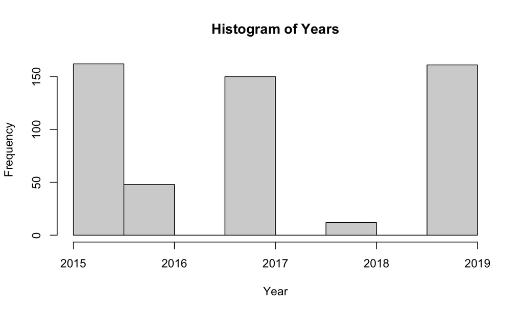

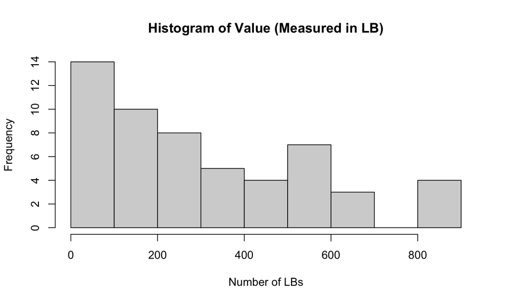

## EDA

- Second step: scatterplot of Chemical Type vs. LBs
- points are jittered to avoid overlap

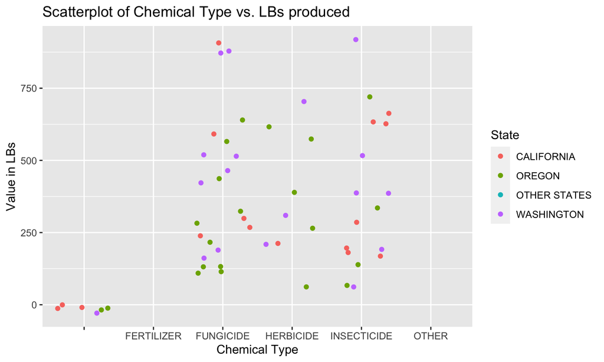

## EDA

- Third step: calculate mean number of lbs for various groups of observations

  | State | mean(Value, na.rm = TRUE) |
  | --- | --- |
  | CALIFORNIA | 331.2500 |
  | OREGON | 285.7143 |
  | OTHER STATES | NaN |
  | WASHINGTON | 433.3333 |

| Year | mean(Value, na.rm = TRUE) |
| --- | --- |
| 2015 | 381.2500 |
| 2016 | 0.0000 |
| 2017 | 388.8889 |
| 2018 | NaN |
| 2019 | 352.9412 |

| Chemical_Type | mean(Value, na.rm = TRUE) |
| --- | --- |
|  | 0.0000 |
| FERTILIZER | NaN |
| FUNGICIDE | 400.0000 |
| HERBICIDE | 377.7778 |
| INSECTICIDE | 382.3529 |
| OTHER | NaN |

## Conclusions

- Lots of NAs in the Value column
- 2016 and 2018 don’t have many observations
- Distribution of lbs of raspberries is right-skewed
- “Other” categories don’t have any observations
- No obvious patterns or trends in the data
- Future analyses may look at other measurement units besides lbs

## References

1. Hadley Wickham, Romain François, Lionel Henry and Kirill Müller (2020). dplyr: A Grammar of Data Manipulation. R package version 1.0.2. https://CRAN.R-project.org/package=dplyr
2. Hao Zhu (2020). kableExtra: Construct Complex Table with ‘kable’ and Pipe Syntax. R package version 1.2.1. https://CRAN.R-project.org/package=kableExtra
3. H. Wickham. ggplot2: Elegant Graphics for Data Analysis. Springer-Verlag New York, 2016.
4. Stefan Milton Bache and Hadley Wickham (2014). magrittr: A Forward-Pipe Operator for R. R package version 1.5. https://CRAN.R-project.org/package=magrittr
5. Wickham et al., (2019). Welcome to the tidyverse. Journal of Open Source Software, 4(43), 1686, https://doi.org/10.21105/joss.01686
6. Yihui Xie (2020). knitr: A General-Purpose Package for Dynamic Report Generation in R. R package version 1.29.